# Chapter 4: Data Manipulation, Wrangling with dplyr

M Affouf

2/13/2018

# part1

## Manipulating Data

So far, we’ve covered how to read in data, and select specific rows and columns.

All of these steps help you set up your analysis or data exploration.

Now we are going to cover manipulating your data and summarizing it using basic statistics and visualizations.

## Sorting and ordering

`sort(x, decreasing=FALSE)`: ‘sort (or order) a vector or factor (partially) into ascending or descending order.’ Note that this returns an object that has been sorted/ordered

`order(...,decreasing=FALSE)`: ‘returns a permutation which rearranges its first argument into ascending or descending order, breaking ties by further arguments.’ Note that this returns the indices corresponding to the sorted data.

## Sorting and ordering

```r
x = c(1,4,7,6,4,12,9,3)
sort(x)
```

```
## [1]  1  3  4  4  6  7  9 12
```

```r
order(x)
```

```
## [1] 1 8 2 5 4 3 7 6
```

Note you would have to assign the sorted variable to a new variable to retain it

## Sorting and ordering

```r
circ = read.csv("charmcitycirc_reduced.csv", header=TRUE,as.is=TRUE)
circ2 = circ[,c("day","date", "orangeAverage","purpleAverage",
              "greenAverage","bannerAverage","daily")]
head(order(circ2$daily,decreasing=TRUE))
```

```
## [1] 888 887 886 971 880 866
```

```r
head(sort(circ2$daily,decreasing=TRUE))
```

```
## [1] 22074.5 21951.0 17580.0 16714.0 16366.5 16149.5
```

The first indicates the rows of `circ2` ordered by daily average ridership. The second displays the actual sorted values of daily average ridership.

## Sorting and ordering

```r
circSorted = circ2[order(circ2$daily,decreasing=TRUE),]
circSorted[1:5,]
```

```
##          day       date orangeAverage purpleAverage greenAverage
## 888 Saturday 06/16/2012        6322.0        7797.0       3338.5
## 887   Friday 06/15/2012        6926.5        8089.5       3485.0
## 886 Thursday 06/14/2012        5617.5        6521.0       2769.5
## 971   Friday 09/07/2012        5717.5        7007.0       2688.5
## 880   Friday 06/08/2012        5782.5        6881.5       2858.0
##     bannerAverage   daily
## 888        4617.0 22074.5
## 887        3450.0 21951.0
## 886        2672.0 17580.0
## 971        1301.0 16714.0
## 880         844.5 16366.5
```

## Sorting and ordering

Note that the row names refer to their previous values. You can do something like this to fix:

```r
rownames(circSorted)=NULL
circSorted[1:5,]
```

```
##        day       date orangeAverage purpleAverage greenAverage
## 1 Saturday 06/16/2012        6322.0        7797.0       3338.5
## 2   Friday 06/15/2012        6926.5        8089.5       3485.0
## 3 Thursday 06/14/2012        5617.5        6521.0       2769.5
## 4   Friday 09/07/2012        5717.5        7007.0       2688.5
## 5   Friday 06/08/2012        5782.5        6881.5       2858.0
##   bannerAverage   daily
## 1        4617.0 22074.5
## 2        3450.0 21951.0
## 3        2672.0 17580.0
## 4        1301.0 16714.0
## 5         844.5 16366.5
```

## Creating categorical variables

However, it’s much easier to use `cut()` to create categorical variables from continuous variables.

‘cut divides the range of x into intervals and codes the values in x according to which interval they fall. The leftmost interval corresponds to level one, the next leftmost to level two and so on.’

```
cut(x, breaks, labels = NULL, include.lowest = FALSE,
  right = TRUE, dig.lab = 3,
  ordered_result = FALSE, ...)
```

## Cut

Now that we know more about factors, `cut()` will make more sense:

```r
x = 1:100
cx = cut(x, breaks=c(0,10,25,50,100))
head(cx)
```

```
## [1] (0,10] (0,10] (0,10] (0,10] (0,10] (0,10]
## Levels: (0,10] (10,25] (25,50] (50,100]
```

```r
table(cx)
```

```
## cx
##   (0,10]  (10,25]  (25,50] (50,100]
##       10       15       25       50
```

We can also leave off the labels

```r
cx = cut(x, breaks=c(0,10,25,50,100), labels=FALSE)
head(cx)
```

```
## [1] 1 1 1 1 1 1
```

```r
table(cx)
```

```
## cx
##  1  2  3  4
## 10 15 25 50
```

Note that you have to specify the endpoints of the data, otherwise some of the categories will not be created

```r
cx = cut(x, breaks=c(10,25,50), labels=FALSE)
head(cx)
```

```
## [1] NA NA NA NA NA NA
```

```r
table(cx)
```

```
## cx
##  1  2
## 15 25
```

```r
table(cx,useNA="ifany")
```

```
## cx
##    1    2 <NA>
##   15   25   60
```

## Adding to data frames

```r
circ2$riderLevels = cut(circ2$daily,
      breaks = c(0,10000,20000,100000))
circ2[1:2,]
```

```
##       day       date orangeAverage purpleAverage greenAverage
## 1  Monday 01/11/2010           952            NA           NA
## 2 Tuesday 01/12/2010           796            NA           NA
##   bannerAverage daily riderLevels
## 1            NA   952   (0,1e+04]
## 2            NA   796   (0,1e+04]
```

```r
table(circ2$riderLevels, useNA="always")
```

```
##
##     (0,1e+04] (1e+04,2e+04] (2e+04,1e+05]          <NA>
##           731           280             2           133
```

## Other manipulations

- `abs(x)`: absolute value
- `sqrt(x)`: square root
- `ceiling(x)`: ceiling(3.475) is 4
- `floor(x)`: floor(3.475) is 3
- `trunc(x)`: trunc(5.99) is 5
- `round(x, digits=n)`: round(3.475, digits=2) is 3.48
- `signif(x, digits=n)`: signif(3.475, digits=2) is 3.5
- `log(x)`: natural logarithm
- `log10(x)`: common logarithm
- `exp(x)`: e^x

(via: http://statmethods.net/management/functions.html)

## Overview

In this module, we will show you how to:

1. Reshaping data from long (tall) to wide (fat)
2. Reshaping data from wide (fat) to long (tall)
3. Merging Data
4. Perform operations by a grouping variable

## Setup

We will show you how to do each operation in base R then show you how to use the `dplyr` or `tidyr` package to do the same operation (if applicable).

See the “Data Wrangling Cheat Sheet using `dplyr` and `tidyr`”:

- https://www.rstudio.com/wp-content/uploads/2015/02/data-wrangling-cheatsheet.pdf

## Load the packages/libraries

```r
library(dplyr)
library(tidyr)
```

## Data used: Charm City Circulator

Let’s read in the Charm City Circulator data:

```r
ex_data = read.csv("Charm_City_Circulator_Ridership.csv", as.is = TRUE)
head(ex_data, 2)
```

```
##       day       date orangeBoardings orangeAlightings orangeAverage
## 1  Monday 01/11/2010             877             1027           952
## 2 Tuesday 01/12/2010             777              815           796
##   purpleBoardings purpleAlightings purpleAverage greenBoardings
## 1              NA               NA            NA             NA
## 2              NA               NA            NA             NA
##   greenAlightings greenAverage bannerBoardings bannerAlightings
## 1              NA           NA              NA               NA
## 2              NA           NA              NA               NA
##   bannerAverage daily
## 1            NA   952
## 2            NA   796
```

## Creating a Date class from a character date

The `lubridate` package is great for dates:

```r
library(lubridate) # great for dates!
ex_data = mutate(ex_data, date = mdy(date))
nrow(ex_data[ is.na(ex_data$date), ])
```

```
## [1] 0
```

```r
head(ex_data$date)
```

```
## [1] "2010-01-11" "2010-01-12" "2010-01-13" "2010-01-14" "2010-01-15"
## [6] "2010-01-16"
```

```r
class(ex_data$date)
```

```
## [1] "Date"
```

## Making column names a little more separated

We will use `str_replace` from `stringr` to put periods in the column names.

```r
library(stringr)
cn = colnames(ex_data)
cn = cn %>%
  str_replace("Board", ".Board") %>%
  str_replace("Alight", ".Alight") %>%
  str_replace("Average", ".Average")
colnames(ex_data) = cn
```

## Removing the daily ridership

We want to look at each ridership, and will removet the `daily` column:

```r
ex_data$daily = NULL
```

## Reshaping data from wide (fat) to long (tall)

See http://www.cookbook-r.com/Manipulating_data/Converting_data_between_wide_and_long_format/

## Reshaping data from wide (fat) to long (tall): base R

The `reshape` command exists. It is a **confusing** function. Don’t use it.

## Reshaping data from wide (fat) to long (tall): tidyr

In `tidyr`, the `gather` function gathers columns into rows.

We want the column names into “`var`” variable in the output dataset and the value in “`number`” variable. We then describe which columns we want to “gather:”

```r
long = gather(ex_data, "var", "number",
              starts_with("orange"),
              starts_with("purple"), starts_with("green"),
              starts_with("banner"))
head(long)
```

```
##         day       date              var number
## 1    Monday 2010-01-11 orange.Boardings    877
## 2   Tuesday 2010-01-12 orange.Boardings    777
## 3 Wednesday 2010-01-13 orange.Boardings   1203
## 4  Thursday 2010-01-14 orange.Boardings   1194
## 5    Friday 2010-01-15 orange.Boardings   1645
## 6  Saturday 2010-01-16 orange.Boardings   1457
```

```r
table(long$var)
```

```
##
## banner.Alightings    banner.Average  banner.Boardings  green.Alightings
##              1146              1146              1146              1146
##     green.Average   green.Boardings orange.Alightings    orange.Average
##              1146              1146              1146              1146
##  orange.Boardings purple.Alightings    purple.Average  purple.Boardings
##              1146              1146              1146              1146
```

## Reshaping data from wide (fat) to long (tall): tidyr

Now each `var` is boardings, averages, or alightings. We want to separate these so we can have these by line.

```r
long = separate_(long, "var", into = c("line", "type"), sep = "[.]")
head(long)
```

```
##         day       date   line      type number
## 1    Monday 2010-01-11 orange Boardings    877
## 2   Tuesday 2010-01-12 orange Boardings    777
## 3 Wednesday 2010-01-13 orange Boardings   1203
## 4  Thursday 2010-01-14 orange Boardings   1194
## 5    Friday 2010-01-15 orange Boardings   1645
## 6  Saturday 2010-01-16 orange Boardings   1457
```

```r
table(long$line)
```

```
##
## banner  green orange purple
##   3438   3438   3438   3438
```

```r
table(long$type)
```

```
##
## Alightings    Average  Boardings
##       4584       4584       4584
```

## Reshaping data from long (tall) to wide (fat): tidyr

In `tidyr`, the `spread` function spreads rows into columns. Now we have a long data set, but we want to separate the Average, Alightings and Boardings into different columns:

```r
# have to remove missing days
wide = filter(long, !is.na(date))
wide = spread(wide, type, number)
head(wide)
```

```
##      day       date   line Alightings Average Boardings
## 1 Friday 2010-01-15 banner         NA      NA        NA
## 2 Friday 2010-01-15  green         NA      NA        NA
## 3 Friday 2010-01-15 orange       1643    1644      1645
## 4 Friday 2010-01-15 purple         NA      NA        NA
## 5 Friday 2010-01-22 banner         NA      NA        NA
## 6 Friday 2010-01-22  green         NA      NA        NA
```

## Reshaping data from long (tall) to wide (fat): tidyr

We can use `rowSums` to see if any values in the row is `NA` and keep if the row, which is a combination of date and line type has any non-missing data.

```r
# wide = wide %>%
#     select(Alightings, Average, Boardings) %>%
#     mutate(good = rowSums(is.na(.)) > 0)
namat = !is.na(select(wide, Alightings, Average, Boardings))
head(namat)
```

```
##   Alightings Average Boardings
## 1      FALSE   FALSE     FALSE
## 2      FALSE   FALSE     FALSE
## 3       TRUE    TRUE      TRUE
## 4      FALSE   FALSE     FALSE
## 5      FALSE   FALSE     FALSE
## 6      FALSE   FALSE     FALSE
```

```r
wide$good = rowSums(namat) > 0
head(wide, 3)
```

```
##      day       date   line Alightings Average Boardings  good
## 1 Friday 2010-01-15 banner         NA      NA        NA FALSE
## 2 Friday 2010-01-15  green         NA      NA        NA FALSE
## 3 Friday 2010-01-15 orange       1643    1644      1645  TRUE
```

## Reshaping data from long (tall) to wide (fat): tidyr

Now we can filter only the good rows and delete the `good` column.

```r
wide = filter(wide, good) %>% select(-good)
head(wide)
```

```
##      day       date   line Alightings Average Boardings
## 1 Friday 2010-01-15 orange       1643  1644.0      1645
## 2 Friday 2010-01-22 orange       1388  1394.5      1401
## 3 Friday 2010-01-29 orange       1322  1332.0      1342
## 4 Friday 2010-02-05 orange       1204  1217.5      1231
## 5 Friday 2010-02-12 orange        678   671.0       664
## 6 Friday 2010-02-19 orange       1647  1642.0      1637
```

## Data Merging/Append in Base R

- Merging - joining data sets together - usually on key variables, usually “id”
- `merge()` is the most common way to do this with data sets
- `rbind`/`cbind` - row/column bind, respectively
  - `rbind` is the equivalent of “appending” in Stata or “setting” in SAS
  - `cbind` allows you to add columns in addition to the previous ways
- `t()` is a function that will transpose the data

## Merging

```r
base <- data.frame(id = 1:10, Age= seq(55,60, length=10))
base[1:2,]
```

```
##   id      Age
## 1  1 55.00000
## 2  2 55.55556
```

```r
visits <- data.frame(id = rep(1:8, 3), visit= rep(1:3, 8),
                    Outcome = seq(10,50, length=24))
visits[1:2,]
```

```
##   id visit  Outcome
## 1  1     1 10.00000
## 2  2     2 11.73913
```

## Merging

```r
merged.data <- merge(base, visits, by="id")
merged.data[1:5,]
```

```
##   id      Age visit  Outcome
## 1  1 55.00000     1 10.00000
## 2  1 55.00000     3 23.91304
## 3  1 55.00000     2 37.82609
## 4  2 55.55556     2 11.73913
## 5  2 55.55556     1 25.65217
```

```r
dim(merged.data)
```

```
## [1] 24  4
```

## Merging

```r
all.data <- merge(base, visits, by="id", all=TRUE)
tail(all.data)
```

```
##    id      Age visit  Outcome
## 21  7 58.33333     2 48.26087
## 22  8 58.88889     2 22.17391
## 23  8 58.88889     1 36.08696
## 24  8 58.88889     3 50.00000
## 25  9 59.44444    NA       NA
## 26 10 60.00000    NA       NA
```

```r
dim(all.data)
```

```
## [1] 26  4
```

## Perform Operations By Groups: base R

The `tapply` command will take in a vector (`X`), perform a function (`FUN`) over an index (`INDEX`):

```r
args(tapply)
```

```
## function (X, INDEX, FUN = NULL, ..., default = NA, simplify = TRUE)
## NULL
```

## Perform Operations By Groups: base R

Let’s get the mean Average ridership by line:

```r
tapply(wide$Average, wide$line, mean, na.rm = TRUE)
```

```
##    banner     green    orange    purple
##  827.2685 1957.7814 3033.1611 4016.9345
```

## Perform Operations By Groups: dplyr

Let’s get the mean Average ridership by line We will use `group_by` to group the data by line, then use `summarize` (or `summarise`) to get the mean Average ridership:

```r
gb = group_by(wide, line)
summarize(gb, mean_avg = mean(Average))
```

```
## # A tibble: 4 x 2
##     line  mean_avg
##    <chr>     <dbl>
## 1 banner  827.2685
## 2  green 1957.7814
## 3 orange 3033.1611
## 4 purple 4016.9345
```

## Perform Operations By Groups: dplyr with piping

Using piping, this is:

```r
wide %>%
  group_by(line) %>%
  summarise(mean_avg = mean(Average))
```

```
## # A tibble: 4 x 2
##     line  mean_avg
##    <chr>     <dbl>
## 1 banner  827.2685
## 2  green 1957.7814
## 3 orange 3033.1611
## 4 purple 4016.9345
```

## Perform Operations By Multiple Groups: dplyr

This can easily be extended using `group_by` with multiple groups. Let’s define the year of riding:

```r
wide = wide %>% mutate(year = year(date),
                       month = month(date))
wide %>%
  group_by(line, year) %>%
  summarise(mean_avg = mean(Average))
```

```
## # A tibble: 13 x 3
## # Groups:   line [?]
##      line  year  mean_avg
##     <chr> <dbl>     <dbl>
##  1 banner  2012  882.0929
##  2 banner  2013  635.3833
##  3  green  2011 1455.1667
##  4  green  2012 2028.7740
##  5  green  2013 2028.5250
##  6 orange  2010 1890.7859
##  7 orange  2011 3061.6556
##  8 orange  2012 4046.4082
##  9 orange  2013 3322.6250
## 10 purple  2010 2577.1000
## 11 purple  2011 4026.9146
## 12 purple  2012 4811.0068
## 13 purple  2013 4045.3833
```

## Perform Operations By Multiple Groups: dplyr

We can then easily plot each day over time:

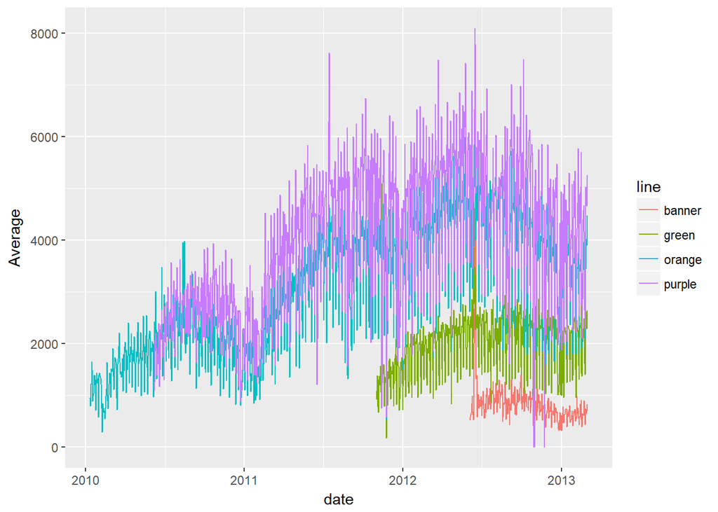

```r
library(ggplot2)
ggplot(aes(x = date, y = Average,
               colour = line), data = wide) + geom_line()
```

## Perform Operations By Multiple Groups: dplyr

Let’s create the middle of the month (the 15th for example), and name it mon.

```r
mon = wide %>%
  dplyr::group_by(line, month, year) %>%
  dplyr::summarise(mean_avg = mean(Average))
mon = mutate(mon,
             mid_month = dmy(paste0("15-", month, "-", year)))
head(mon)
```

```
## # A tibble: 6 x 5
## # Groups:   line, month [6]
##     line month  year  mean_avg  mid_month
##    <chr> <dbl> <dbl>     <dbl>     <date>
## 1 banner     1  2013  610.3226 2013-01-15
## 2 banner     2  2013  656.4643 2013-02-15
## 3 banner     3  2013  822.0000 2013-03-15
## 4 banner     6  2012 1288.1296 2012-06-15
## 5 banner     7  2012  874.4839 2012-07-15
## 6 banner     8  2012  929.4355 2012-08-15
```

## Perform Operations By Multiple Groups: dplyr

We can then easily plot the mean of each month to see a smoother output:

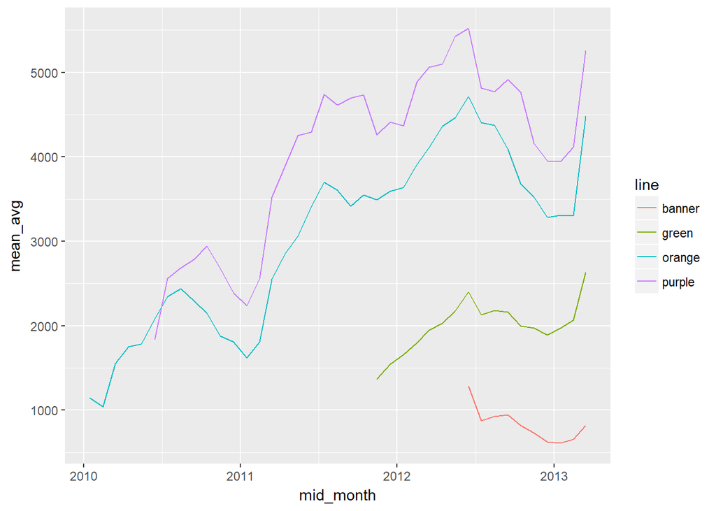

```r
ggplot(aes(x = mid_month,
               y = mean_avg,
               colour = line), data = mon) + geom_line()
```

## Bonus! Points with a smoother!

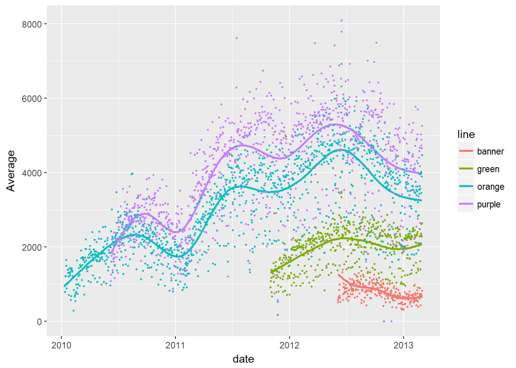

```r
ggplot(aes(x = date, y = Average, colour = line),
           data = wide) + geom_smooth(se = FALSE) +
  geom_point(size = .5)
```

# Part2

## Packages

```r
library(ggplot2)
library(dplyr)
library(nycflights13)
```

> These notes are based on the following [introduction to dplyr vignette](https://cran.rstudio.com/web/packages/dplyr/vignettes/introduction.html).

> For a more thorough discussion, you can look at the [Data transformation chapter](http://r4ds.had.co.nz/transform.html) of R for Data Science

> The [dplyr and tidyr cheatsheet](https://www.rstudio.com/wp-content/uploads/2015/02/data-wrangling-cheatsheet.pdf) is another fantastic reference.

## Basics of dplyr

The `dplyr` package introduces 5 basic verbs that help to streamline the data manipulation process.

- `filter(<data.frame>, <criteria>)`
  - Selects a subset of rows from a `<data.frame>` based on expressions giving filtering `<criteria>`
- `arrange()`
- `select()`
- `mutate()`
- `summarise()`

It also has several other functions such as `slice()`, `rename()`, `transmute()`, `sample_n()` and `sample_frac()`, all of which you may find useful.

## Exploring the `nycflights13` data

We’ll illustrate the basics of `dplyr` using the `flights` data. This dataset contains information on 336776 that departed from New York City in 2013.

```r
head(flights)
```

```
## # A tibble: 6 x 19
##    year month   day dep_time sched_dep_time dep_delay arr_time
##   <int> <int> <int>    <int>          <int>     <dbl>    <int>
## 1  2013     1     1      517            515         2      830
## 2  2013     1     1      533            529         4      850
## 3  2013     1     1      542            540         2      923
## 4  2013     1     1      544            545        -1     1004
## 5  2013     1     1      554            600        -6      812
## 6  2013     1     1      554            558        -4      740
## # ... with 12 more variables: sched_arr_time <int>, arr_delay <dbl>,
## #   carrier <chr>, flight <int>, tailnum <chr>, origin <chr>, dest <chr>,
## #   air_time <dbl>, distance <dbl>, hour <dbl>, minute <dbl>,
## #   time_hour <dttm>
```

```r
summary(flights)
```

```
##       year          month             day           dep_time
##  Min.   :2013   Min.   : 1.000   Min.   : 1.00   Min.   :   1
##  1st Qu.:2013   1st Qu.: 4.000   1st Qu.: 8.00   1st Qu.: 907
##  Median :2013   Median : 7.000   Median :16.00   Median :1401
##  Mean   :2013   Mean   : 6.549   Mean   :15.71   Mean   :1349
##  3rd Qu.:2013   3rd Qu.:10.000   3rd Qu.:23.00   3rd Qu.:1744
##  Max.   :2013   Max.   :12.000   Max.   :31.00   Max.   :2400
##                                                  NA's   :8255
##  sched_dep_time   dep_delay          arr_time    sched_arr_time
##  Min.   : 106   Min.   : -43.00   Min.   :   1   Min.   :   1
##  1st Qu.: 906   1st Qu.:  -5.00   1st Qu.:1104   1st Qu.:1124
##  Median :1359   Median :  -2.00   Median :1535   Median :1556
##  Mean   :1344   Mean   :  12.64   Mean   :1502   Mean   :1536
##  3rd Qu.:1729   3rd Qu.:  11.00   3rd Qu.:1940   3rd Qu.:1945
##  Max.   :2359   Max.   :1301.00   Max.   :2400   Max.   :2359
##                 NA's   :8255      NA's   :8713
##    arr_delay          carrier              flight       tailnum
##  Min.   : -86.000   Length:336776      Min.   :   1   Length:336776
##  1st Qu.: -17.000   Class :character   1st Qu.: 553   Class :character
##  Median :  -5.000   Mode  :character   Median :1496   Mode  :character
##  Mean   :   6.895                      Mean   :1972
##  3rd Qu.:  14.000                      3rd Qu.:3465
##  Max.   :1272.000                      Max.   :8500
##  NA's   :9430
##     origin              dest              air_time        distance
##  Length:336776      Length:336776      Min.   : 20.0   Min.   :  17
##  Class :character   Class :character   1st Qu.: 82.0   1st Qu.: 502
##  Mode  :character   Mode  :character   Median :129.0   Median : 872
##                                        Mean   :150.7   Mean   :1040
##                                        3rd Qu.:192.0   3rd Qu.:1389
##                                        Max.   :695.0   Max.   :4983
##                                        NA's   :9430
##       hour           minute        time_hour
##  Min.   : 1.00   Min.   : 0.00   Min.   :2013-01-01 05:00:00
##  1st Qu.: 9.00   1st Qu.: 8.00   1st Qu.:2013-04-04 13:00:00
##  Median :13.00   Median :29.00   Median :2013-07-03 10:00:00
##  Mean   :13.18   Mean   :26.23   Mean   :2013-07-03 05:02:36
##  3rd Qu.:17.00   3rd Qu.:44.00   3rd Qu.:2013-10-01 07:00:00
##  Max.   :23.00   Max.   :59.00   Max.   :2013-12-31 23:00:00
##
```

## Data subsets with `filter()`

`filter()` allows you to select a subset of rows in a data frame. The first argument is the name of the data frame. The second and subsequent arguments are the expressions that filter the data frame:

Let’s look at all the flights that departed on January 1st and where the departure time was delayed by at least 15 minutes.

```r
filter(flights,
       month == 1,
       day == 1,
       dep_delay >= 15)
```

```
## # A tibble: 163 x 19
##     year month   day dep_time sched_dep_time dep_delay arr_time
##    <int> <int> <int>    <int>          <int>     <dbl>    <int>
##  1  2013     1     1      632            608        24      740
##  2  2013     1     1      732            645        47     1011
##  3  2013     1     1      749            710        39      939
##  4  2013     1     1      811            630       101     1047
##  5  2013     1     1      826            715        71     1136
##  6  2013     1     1      848           1835       853     1001
##  7  2013     1     1      903            820        43     1045
##  8  2013     1     1      906            843        23     1134
##  9  2013     1     1      909            810        59     1331
## 10  2013     1     1      920            905        15     1039
## # ... with 153 more rows, and 12 more variables: sched_arr_time <int>,
## #   arr_delay <dbl>, carrier <chr>, flight <int>, tailnum <chr>,
## #   origin <chr>, dest <chr>, air_time <dbl>, distance <dbl>, hour <dbl>,
## #   minute <dbl>, time_hour <dttm>
```

How does this compare to other syntax we’ve learned about?

```r
# This gets clunky fast...
flights[flights$month == 1 & flights$day == 1 & flights$dep_delay >= 15, ]
```

```
## # A tibble: 167 x 19
##     year month   day dep_time sched_dep_time dep_delay arr_time
##    <int> <int> <int>    <int>          <int>     <dbl>    <int>
##  1  2013     1     1      632            608        24      740
##  2  2013     1     1      732            645        47     1011
##  3  2013     1     1      749            710        39      939
##  4  2013     1     1      811            630       101     1047
##  5  2013     1     1      826            715        71     1136
##  6  2013     1     1      848           1835       853     1001
##  7  2013     1     1      903            820        43     1045
##  8  2013     1     1      906            843        23     1134
##  9  2013     1     1      909            810        59     1331
## 10  2013     1     1      920            905        15     1039
## # ... with 157 more rows, and 12 more variables: sched_arr_time <int>,
## #   arr_delay <dbl>, carrier <chr>, flight <int>, tailnum <chr>,
## #   origin <chr>, dest <chr>, air_time <dbl>, distance <dbl>, hour <dbl>,
## #   minute <dbl>, time_hour <dttm>
```

```r
subset(flights, month == 1 & day == 1 & dep_delay >= 15)
```

```
## # A tibble: 163 x 19
##     year month   day dep_time sched_dep_time dep_delay arr_time
##    <int> <int> <int>    <int>          <int>     <dbl>    <int>
##  1  2013     1     1      632            608        24      740
##  2  2013     1     1      732            645        47     1011
##  3  2013     1     1      749            710        39      939
##  4  2013     1     1      811            630       101     1047
##  5  2013     1     1      826            715        71     1136
##  6  2013     1     1      848           1835       853     1001
##  7  2013     1     1      903            820        43     1045
##  8  2013     1     1      906            843        23     1134
##  9  2013     1     1      909            810        59     1331
## 10  2013     1     1      920            905        15     1039
## # ... with 153 more rows, and 12 more variables: sched_arr_time <int>,
## #   arr_delay <dbl>, carrier <chr>, flight <int>, tailnum <chr>,
## #   origin <chr>, dest <chr>, air_time <dbl>, distance <dbl>, hour <dbl>,
## #   minute <dbl>, time_hour <dttm>
```

## Rearrange rows with `arrange()`

You can think of `arrange()` as a “sort by” operation. This function takes a data frame and a set of column names by which to order the data. Later columns are used to break ties (i.e., order within) earlier columns.

Here’s an example that arranges the data in order of departure date.

```r
arrange(flights, year, month, day)
```

```
## # A tibble: 336,776 x 19
##     year month   day dep_time sched_dep_time dep_delay arr_time
##    <int> <int> <int>    <int>          <int>     <dbl>    <int>
##  1  2013     1     1      517            515         2      830
##  2  2013     1     1      533            529         4      850
##  3  2013     1     1      542            540         2      923
##  4  2013     1     1      544            545        -1     1004
##  5  2013     1     1      554            600        -6      812
##  6  2013     1     1      554            558        -4      740
##  7  2013     1     1      555            600        -5      913
##  8  2013     1     1      557            600        -3      709
##  9  2013     1     1      557            600        -3      838
## 10  2013     1     1      558            600        -2      753
## # ... with 336,766 more rows, and 12 more variables: sched_arr_time <int>,
## #   arr_delay <dbl>, carrier <chr>, flight <int>, tailnum <chr>,
## #   origin <chr>, dest <chr>, air_time <dbl>, distance <dbl>, hour <dbl>,
## #   minute <dbl>, time_hour <dttm>
```

You can also add expressions to the `arrange()` command. For instance, if you wanted to sort the flights in *descending* order of departure delay, you could use the `desc()` command:

```r
arrange(flights, desc(dep_delay))
```

```
## # A tibble: 336,776 x 19
##     year month   day dep_time sched_dep_time dep_delay arr_time
##    <int> <int> <int>    <int>          <int>     <dbl>    <int>
##  1  2013     1     9      641            900      1301     1242
##  2  2013     6    15     1432           1935      1137     1607
##  3  2013     1    10     1121           1635      1126     1239
##  4  2013     9    20     1139           1845      1014     1457
##  5  2013     7    22      845           1600      1005     1044
##  6  2013     4    10     1100           1900       960     1342
##  7  2013     3    17     2321            810       911      135
##  8  2013     6    27      959           1900       899     1236
##  9  2013     7    22     2257            759       898      121
## 10  2013    12     5      756           1700       896     1058
## # ... with 336,766 more rows, and 12 more variables: sched_arr_time <int>,
## #   arr_delay <dbl>, carrier <chr>, flight <int>, tailnum <chr>,
## #   origin <chr>, dest <chr>, air_time <dbl>, distance <dbl>, hour <dbl>,
## #   minute <dbl>, time_hour <dttm>
```

## Select columns with `select()`

The `select()` function can be thought of as a substitute for the `select =` argument in a `subset()` command. One notable difference is the more flexible syntax offered by `select()`.

```r
# Select columns by name
select(flights, year, month, day)
```

```
## # A tibble: 336,776 x 3
##     year month   day
##    <int> <int> <int>
##  1  2013     1     1
##  2  2013     1     1
##  3  2013     1     1
##  4  2013     1     1
##  5  2013     1     1
##  6  2013     1     1
##  7  2013     1     1
##  8  2013     1     1
##  9  2013     1     1
## 10  2013     1     1
## # ... with 336,766 more rows
```

```r
# Select all columns between year and day (inclusive)
select(flights, year:day)
```

```
## # A tibble: 336,776 x 3
##     year month   day
##    <int> <int> <int>
##  1  2013     1     1
##  2  2013     1     1
##  3  2013     1     1
##  4  2013     1     1
##  5  2013     1     1
##  6  2013     1     1
##  7  2013     1     1
##  8  2013     1     1
##  9  2013     1     1
## 10  2013     1     1
## # ... with 336,766 more rows
```

```r
# Select all columns except those from year to day (inclusive)
select(flights, -(year:day))
```

```
## # A tibble: 336,776 x 16
##    dep_time sched_dep_time dep_delay arr_time sched_arr_time arr_delay
##       <int>          <int>     <dbl>    <int>          <int>     <dbl>
##  1      517            515         2      830            819        11
##  2      533            529         4      850            830        20
##  3      542            540         2      923            850        33
##  4      544            545        -1     1004           1022       -18
##  5      554            600        -6      812            837       -25
##  6      554            558        -4      740            728        12
##  7      555            600        -5      913            854        19
##  8      557            600        -3      709            723       -14
##  9      557            600        -3      838            846        -8
## 10      558            600        -2      753            745         8
## # ... with 336,766 more rows, and 10 more variables: carrier <chr>,
## #   flight <int>, tailnum <chr>, origin <chr>, dest <chr>, air_time <dbl>,
## #   distance <dbl>, hour <dbl>, minute <dbl>, time_hour <dttm>
```

You can use helper functions such as `starts_with()`, `ends_with()`, `matches()` and `contains()` as part of your select call.

- `starts_with("abc")`: matches names that begin with “abc”.
- `ends_with("xyz")`: matches names that end with “xyz”.
- `contains("ijk")`: matches names that contain “ijk”.
- `matches("(.)\\1")`: selects variables that match a regular expression. This one matches any variables that contain repeated characters. You’ll learn more about regular expressions in strings.
- `num_range("x", 1:3)` matches x1, x2 and x3.

```r
# Pull all of the departure-related columns
select(flights, contains("dep"))
```

```
## # A tibble: 336,776 x 3
##    dep_time sched_dep_time dep_delay
##       <int>          <int>     <dbl>
##  1      517            515         2
##  2      533            529         4
##  3      542            540         2
##  4      544            545        -1
##  5      554            600        -6
##  6      554            558        -4
##  7      555            600        -5
##  8      557            600        -3
##  9      557            600        -3
## 10      558            600        -2
## # ... with 336,766 more rows
```

```r
# Pull all of the arrival and departure related columns
select(flights,
       contains("dep"),
       contains("arr"))
```

```
## # A tibble: 336,776 x 7
##    dep_time sched_dep_time dep_delay arr_time sched_arr_time arr_delay
##       <int>          <int>     <dbl>    <int>          <int>     <dbl>
##  1      517            515         2      830            819        11
##  2      533            529         4      850            830        20
##  3      542            540         2      923            850        33
##  4      544            545        -1     1004           1022       -18
##  5      554            600        -6      812            837       -25
##  6      554            558        -4      740            728        12
##  7      555            600        -5      913            854        19
##  8      557            600        -3      709            723       -14
##  9      557            600        -3      838            846        -8
## 10      558            600        -2      753            745         8
## # ... with 336,766 more rows, and 1 more variables: carrier <chr>
```

## Add new columns with `mutate()`

You can think of `mutate()` as an improved version of the `transform()` command. We’ll illustrate a couple of advantages.

```r
# Calculate delay reduction in travel (gain) and average speed
mutate(flights,
  gain = arr_delay - dep_delay,
  speed = distance / air_time * 60)
```

```
## # A tibble: 336,776 x 21
##     year month   day dep_time sched_dep_time dep_delay arr_time
##    <int> <int> <int>    <int>          <int>     <dbl>    <int>
##  1  2013     1     1      517            515         2      830
##  2  2013     1     1      533            529         4      850
##  3  2013     1     1      542            540         2      923
##  4  2013     1     1      544            545        -1     1004
##  5  2013     1     1      554            600        -6      812
##  6  2013     1     1      554            558        -4      740
##  7  2013     1     1      555            600        -5      913
##  8  2013     1     1      557            600        -3      709
##  9  2013     1     1      557            600        -3      838
## 10  2013     1     1      558            600        -2      753
## # ... with 336,766 more rows, and 14 more variables: sched_arr_time <int>,
## #   arr_delay <dbl>, carrier <chr>, flight <int>, tailnum <chr>,
## #   origin <chr>, dest <chr>, air_time <dbl>, distance <dbl>, hour <dbl>,
## #   minute <dbl>, time_hour <dttm>, gain <dbl>, speed <dbl>
```

An interesting thing that you can do with `mutate()` but not `transform()` is to create columns based on transformations of new columns that you just created within the same command. Here’s an example.

```r
mutate(flights,
  gain = arr_delay - dep_delay,
  gain_per_hour = gain / (air_time / 60)
)
```

```
## # A tibble: 336,776 x 21
##     year month   day dep_time sched_dep_time dep_delay arr_time
##    <int> <int> <int>    <int>          <int>     <dbl>    <int>
##  1  2013     1     1      517            515         2      830
##  2  2013     1     1      533            529         4      850
##  3  2013     1     1      542            540         2      923
##  4  2013     1     1      544            545        -1     1004
##  5  2013     1     1      554            600        -6      812
##  6  2013     1     1      554            558        -4      740
##  7  2013     1     1      555            600        -5      913
##  8  2013     1     1      557            600        -3      709
##  9  2013     1     1      557            600        -3      838
## 10  2013     1     1      558            600        -2      753
## # ... with 336,766 more rows, and 14 more variables: sched_arr_time <int>,
## #   arr_delay <dbl>, carrier <chr>, flight <int>, tailnum <chr>,
## #   origin <chr>, dest <chr>, air_time <dbl>, distance <dbl>, hour <dbl>,
## #   minute <dbl>, time_hour <dttm>, gain <dbl>, gain_per_hour <dbl>
```

Here’s what would happen if we tried doing the same thing with the `transform()` command:

```r
transform(flights,
  gain = arr_delay - dep_delay,
  gain_per_hour = gain / (air_time / 60)
)
# Error in eval(expr, envir, enclos) : object 'gain' not found
```

## `transmute()`

If all you want to keep from the `mutate()` are the newly formed variables, you can either chain together a `mutate()` with a `select()`, or you can directly use the `transmute()` command.

```r
transmute(flights,
  gain = arr_delay - dep_delay,
  gain_per_hour = gain / (air_time / 60)
)
```

```
## # A tibble: 336,776 x 2
##     gain gain_per_hour
##    <dbl>         <dbl>
##  1     9      2.378855
##  2    16      4.229075
##  3    31     11.625000
##  4   -17     -5.573770
##  5   -19     -9.827586
##  6    16      6.400000
##  7    24      9.113924
##  8   -11    -12.452830
##  9    -5     -2.142857
## 10    10      4.347826
## # ... with 336,766 more rows
```

## Summary tables with summarise()

You can think of `summarise()` as performing a similar operation to the `plyr::ddply()` function. On its own, `summarise()` just returns a 1-line summary data frame.

```r
summarise(flights,
          mean_dep_delay = mean(dep_delay, na.rm = TRUE),
          mean_arr_delay = mean(arr_delay, na.rm = TRUE)
          )
```

```
## # A tibble: 1 x 2
##   mean_dep_delay mean_arr_delay
##            <dbl>          <dbl>
## 1       12.63907       6.895377
```

## Using `group_by()`

To obtain summaries within some grouping scheme, you can use the `group_by()` command followed by `summarise()`.

Here we’ll illustrate how this approach can be used to better understand the association between arrival delays and distance traveled.

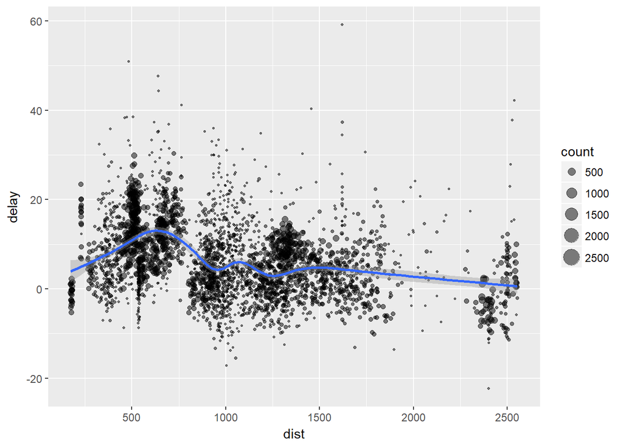

```r
# Form a summary table showing the number of flights,
# average distance, and arrival delay for each airplane

by_tailnum <- group_by(flights, tailnum)
delay <- summarise(by_tailnum,
  count = n(),
  dist = mean(distance, na.rm = TRUE),
  delay = mean(arr_delay, na.rm = TRUE))

# Subset the data to only include frequently flown planes
# and distances < 3000
delay <- filter(delay, count > 20, dist < 3000)

# Plot
ggplot(delay, aes(dist, delay)) +
  geom_point(aes(size = count), alpha = 1/2) +
  geom_smooth() +
  scale_size_area()
```

## Handy summary functions

In addition to functions such as `min()`, `max()`, …, `median()` etc., you can also use the following, which are enabled by the `dplyr` library:

- `n()`: the number of observations in the current group
- `n_distinct(x)` :the number of unique values in x.
- `first(x)`, `last(x)` and `nth(x, n)` - these work similarly to `x[1]`, `x[length(x)]`, and `x[n]` but give you more control over the result if the value is missing.

You can use these functions to, for instance, count the number of planes and number of flights for each possible destination:

```r
destinations <- group_by(flights, dest)

summarise(destinations,
  planes = n_distinct(tailnum),
  flights = n()
)
```

```
## # A tibble: 105 x 3
##     dest planes flights
##    <chr>  <int>   <int>
##  1   ABQ    108     254
##  2   ACK     58     265
##  3   ALB    172     439
##  4   ANC      6       8
##  5   ATL   1180   17215
##  6   AUS    993    2439
##  7   AVL    159     275
##  8   BDL    186     443
##  9   BGR     46     375
## 10   BHM     45     297
## # ... with 95 more rows
```

## Successive summaries

When you group by multiple variables, each summary peels off one level of the grouping. That makes it easy to progressively roll-up a dataset:

```r
daily <- group_by(flights, year, month, day)

# Tabulate number of flights on each day
per_day   <- summarise(daily, flights = n())
per_day
```

```
## # A tibble: 365 x 4
## # Groups:   year, month [?]
##     year month   day flights
##    <int> <int> <int>   <int>
##  1  2013     1     1     842
##  2  2013     1     2     943
##  3  2013     1     3     914
##  4  2013     1     4     915
##  5  2013     1     5     720
##  6  2013     1     6     832
##  7  2013     1     7     933
##  8  2013     1     8     899
##  9  2013     1     9     902
## 10  2013     1    10     932
## # ... with 355 more rows
```

```r
# Tabulate number of flights on each month
per_month <- summarise(per_day, flights = sum(flights))
per_month
```

```
## # A tibble: 12 x 3
## # Groups:   year [?]
##     year month flights
##    <int> <int>   <int>
##  1  2013     1   27004
##  2  2013     2   24951
##  3  2013     3   28834
##  4  2013     4   28330
##  5  2013     5   28796
##  6  2013     6   28243
##  7  2013     7   29425
##  8  2013     8   29327
##  9  2013     9   27574
## 10  2013    10   28889
## 11  2013    11   27268
## 12  2013    12   28135
```

```r
# Total number of flights that year
per_year  <- summarise(per_month, flights = sum(flights))
per_year
```

```
## # A tibble: 1 x 2
##    year flights
##   <int>   <int>
## 1  2013  336776
```

## `distinct()`

`distinct()` allows you to identify the unique values of variables (or combinations of variables) in your data.

```r
# How many different planes departed from NYC airports
# in 2013?
distinct(flights, tailnum)
```

```
## # A tibble: 4,044 x 1
##    tailnum
##      <chr>
##  1  N14228
##  2  N24211
##  3  N619AA
##  4  N804JB
##  5  N668DN
##  6  N39463
##  7  N516JB
##  8  N829AS
##  9  N593JB
## 10  N3ALAA
## # ... with 4,034 more rows
```

```r
# How many distinct (origin, dest) pairs were there?
distinct(flights, origin, dest)
```

```
## # A tibble: 224 x 2
##    origin  dest
##     <chr> <chr>
##  1    EWR   IAH
##  2    LGA   IAH
##  3    JFK   MIA
##  4    JFK   BQN
##  5    LGA   ATL
##  6    EWR   ORD
##  7    EWR   FLL
##  8    LGA   IAD
##  9    JFK   MCO
## 10    LGA   ORD
## # ... with 214 more rows
```

## `rename()`

We’ve done a lot of variable renaming in this class. In most of the cases we’ve renamed all of the columns all at once. If we want to change only a few column names, this can get frustrating. `rename()` addresses precisely this issue.

```r
rename(flights,
       yr = year,
       dep.time = dep_time)
```

```
## # A tibble: 336,776 x 19
##       yr month   day dep.time sched_dep_time dep_delay arr_time
##    <int> <int> <int>    <int>          <int>     <dbl>    <int>
##  1  2013     1     1      517            515         2      830
##  2  2013     1     1      533            529         4      850
##  3  2013     1     1      542            540         2      923
##  4  2013     1     1      544            545        -1     1004
##  5  2013     1     1      554            600        -6      812
##  6  2013     1     1      554            558        -4      740
##  7  2013     1     1      555            600        -5      913
##  8  2013     1     1      557            600        -3      709
##  9  2013     1     1      557            600        -3      838
## 10  2013     1     1      558            600        -2      753
## # ... with 336,766 more rows, and 12 more variables: sched_arr_time <int>,
## #   arr_delay <dbl>, carrier <chr>, flight <int>, tailnum <chr>,
## #   origin <chr>, dest <chr>, air_time <dbl>, distance <dbl>, hour <dbl>,
## #   minute <dbl>, time_hour <dttm>
```

## Piping (chaining)

In this section we’ll introduce the `%>%` (“pipe”) command, which you’ll quickly find indispensible when chaining together multiple operations.

To illustrate a use case, suppose we wanted to do some grouping, sub-setting, summarizing, and then further filtering of the summary. For instance, we might be interested in identifying days in 2013 where the average arrival or departure delay was especially high.

Here’s one approach.

```r
# Group by day of the year
a1 <- group_by(flights, year, month, day)

# Select just the arrival and departure delay columns
a2 <- select(a1, arr_delay, dep_delay)
# Calculate average delays
a3 <- summarise(a2,
  mean_arr_delay = mean(arr_delay, na.rm = TRUE),
  mean_dep_delay = mean(dep_delay, na.rm = TRUE))

# Filter to the days where the average delay was at least 30 mins
a4 <- filter(a3, mean_arr_delay > 30 | mean_dep_delay > 30)
```

Here’s another approach, which wraps all of the functions together to avoid having to create intermediate variables (`a1`, `a2` and `a3`) during the computation.

```r
filter(
  summarise(
    select(
      group_by(flights, year, month, day),
      arr_delay, dep_delay
    ),
    mean_arr_delay = mean(arr_delay, na.rm = TRUE),
    mean_dep_delay = mean(dep_delay, na.rm = TRUE)
  ),
  mean_arr_delay > 30 | mean_dep_delay > 30
)
```

```
## # A tibble: 49 x 5
## # Groups:   year, month [11]
##     year month   day mean_arr_delay mean_dep_delay
##    <int> <int> <int>          <dbl>          <dbl>
##  1  2013     1    16       34.24736       24.61287
##  2  2013     1    31       32.60285       28.65836
##  3  2013     2    11       36.29009       39.07360
##  4  2013     2    27       31.25249       37.76327
##  5  2013     3     8       85.86216       83.53692
##  6  2013     3    18       41.29189       30.11796
##  7  2013     4    10       38.41231       33.02368
##  8  2013     4    12       36.04814       34.83843
##  9  2013     4    18       36.02848       34.91536
## 10  2013     4    19       47.91170       46.12783
## # ... with 39 more rows
```

While this performs the exact same operation, it’s nearly impossible to read. This is largely due to the fact that you have to parse the operation from the inside out, rather than left-to-right or top-to-bottom.

A much better approach is to use `%>%`, which is automatically loaded when you load `dplyr`. Essentially, given a function `f(x, y)`, `x %>% f(y)` is interpreted as `f(x, y)`. This allows us to chain operations together using much more readable syntax.

```r
flights %>%
  group_by(year, month, day) %>%
  select(arr_delay, dep_delay) %>%
  summarise(
    mean_arr_delay = mean(arr_delay, na.rm = TRUE),
    mean_dep_delay = mean(dep_delay, na.rm = TRUE)
  ) %>%
  filter(mean_arr_delay > 30 | mean_dep_delay > 30)
```

```
## # A tibble: 49 x 5
## # Groups:   year, month [11]
##     year month   day mean_arr_delay mean_dep_delay
##    <int> <int> <int>          <dbl>          <dbl>
##  1  2013     1    16       34.24736       24.61287
##  2  2013     1    31       32.60285       28.65836
##  3  2013     2    11       36.29009       39.07360
##  4  2013     2    27       31.25249       37.76327
##  5  2013     3     8       85.86216       83.53692
##  6  2013     3    18       41.29189       30.11796
##  7  2013     4    10       38.41231       33.02368
##  8  2013     4    12       36.04814       34.83843
##  9  2013     4    18       36.02848       34.91536
## 10  2013     4    19       47.91170       46.12783
## # ... with 39 more rows
```

## Example: delay gain per hour

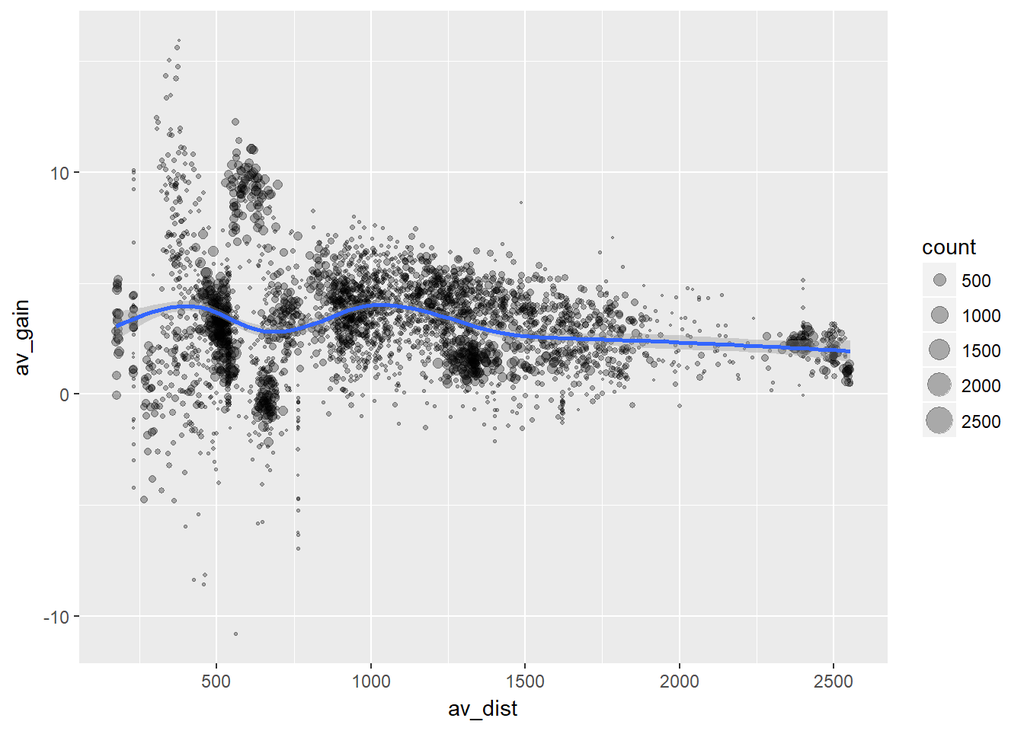

```r
gain.df <- flights %>%
  mutate(gain = dep_delay - arr_delay,
         gain_per_hour = gain / (air_time / 60)) %>%
  group_by(tailnum) %>%
  summarise(count = n(),
            av_gain = mean(gain_per_hour, na.rm = TRUE),
            av_dep_delay = mean(dep_delay, na.rm = TRUE),
            av_arr_delay = mean(arr_delay, na.rm = TRUE),
            av_dist = mean(distance)
  ) %>%
  filter(count > 10, av_dist < 3000)

ggplot(gain.df, aes(x = av_dist, y = av_gain, size = count)) +
  geom_point(alpha = 0.3) +
  scale_size_area() +
  geom_smooth(show.legend = FALSE)
```

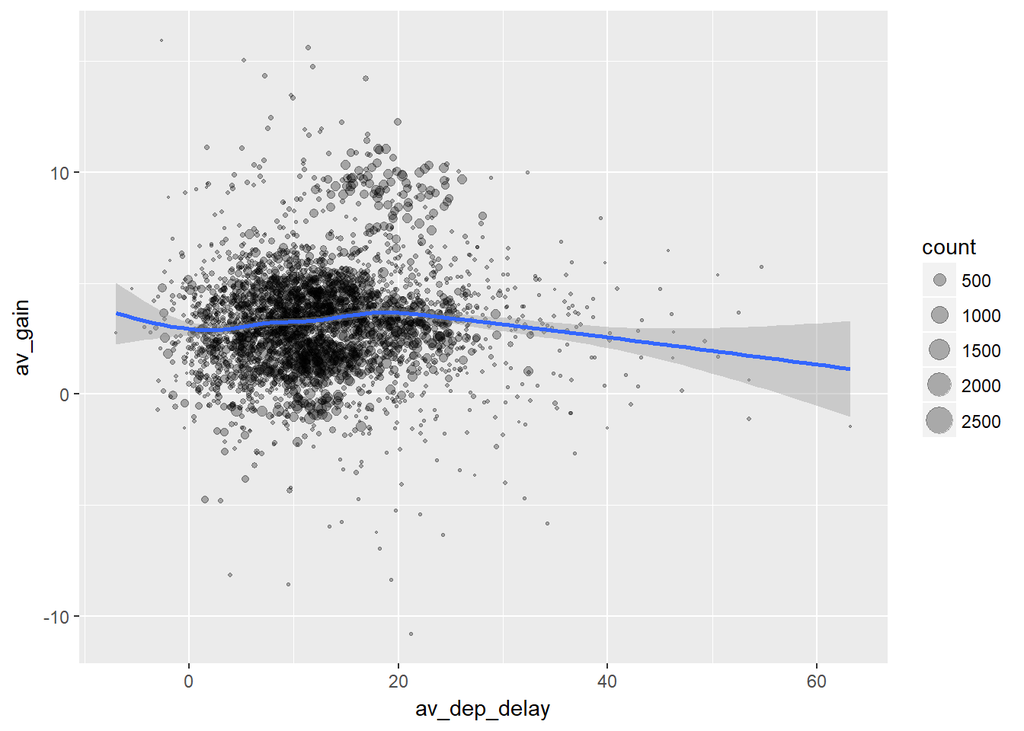

```r
ggplot(gain.df, aes(x = av_dep_delay, y = av_gain, size = count)) +
  geom_point(alpha = 0.3) +
  scale_size_area() +
  geom_smooth(show.legend = FALSE)
```

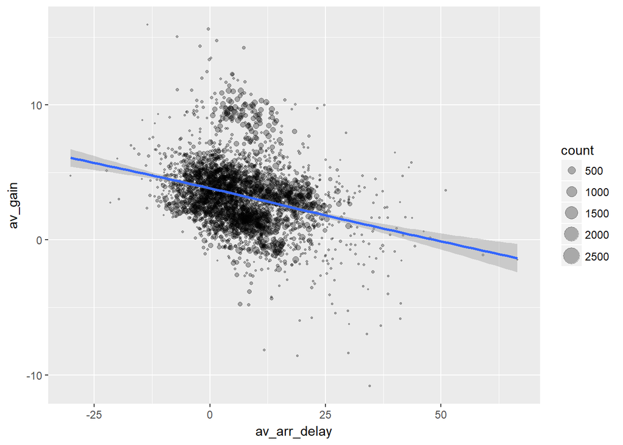

```r
ggplot(gain.df, aes(x = av_arr_delay, y = av_gain, size = count)) +
  geom_point(alpha = 0.3) +
  scale_size_area() +
  geom_smooth(show.legend = FALSE)
```

## Example: average delay time for each origin, destination

In this example we’ll pipe a summary table directly into a ggplot call.

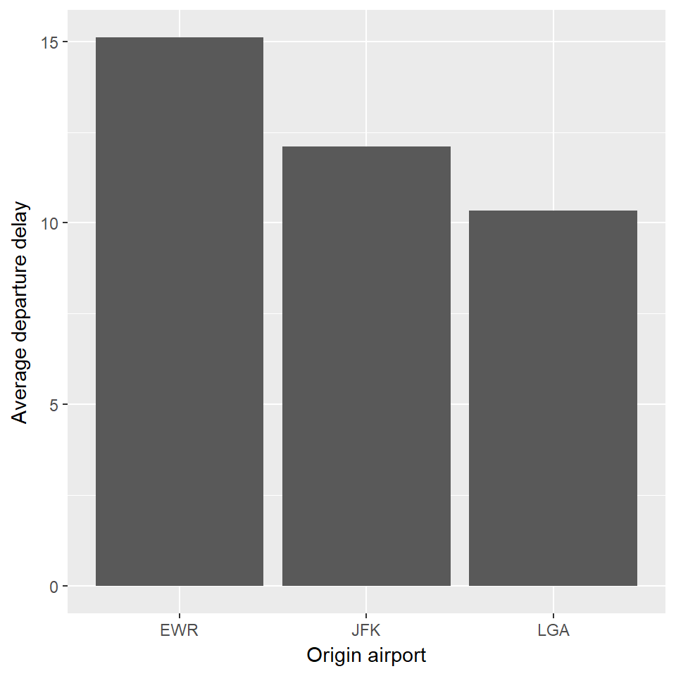

```r
flights %>%
  group_by(origin) %>%
  summarise(av_dep_delay = mean(dep_delay, na.rm = TRUE)) %>%
  ggplot(aes(x = origin, y = av_dep_delay)) +
  geom_bar(stat = "identity") +
  ylab("Average departure delay") +
  xlab("Origin airport")
```

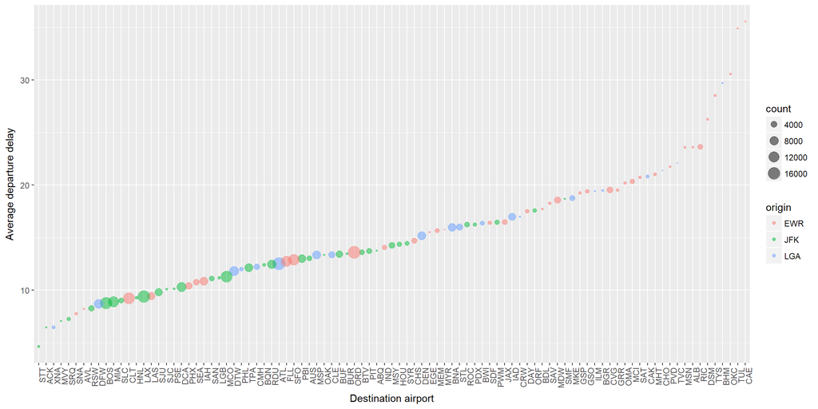

```r
flights %>%
  group_by(dest) %>%
  summarise(av_dep_delay = mean(dep_delay, na.rm = TRUE),
            origin = first(origin),
            count = n()) %>%
  mutate(dest = reorder(dest, av_dep_delay)) %>%
  filter(count > 50) %>%
  ggplot(aes(x = dest, y = av_dep_delay,
             colour = origin, size = count)) +
  geom_point(alpha = 0.5) +
  scale_size_area() +
  ylab("Average departure delay") +
  xlab("Destination airport") +
  theme(axis.text.x = element_text(angle = 90, hjust = 1))
```